# Pear microbial communities!

# What about beta diversity ~ microbial community turnover (beta diversity) ~

We’re also curious how dispersal limitation and environmental factors including surrounding agricultural land use and climatic variables influence microbial community turnover compared to the influence of farm managment on microbial communities across our study extent. First we explore the distance decay of community similarity across our sites using principle coordinates of neighborhood matrix.

The PCNM functions are used to express distances in rectangular form that is similar to normal explanatory variables used in, e.g., constrained ordination (rda, cca and capscale) or univariate regression (lm) together with environmental variables (row weights should be supplied with cca; see Examples). This is regarded as a more powerful method than forcing rectangular environmental data into distances and using them in partial mantel analysis (mantel.partial) together with geographic distances (Legendre et al. 2008, but see Tuomisto & Ruokolainen 2008).

PCNM - powerful tool to investigate the spatial scales of autocorrelation (Legendre, Borcard, & Peres-Neto 2008) [PCNM R documentation](https://www.rdocumentation.org/packages/vegan/versions/2.4-2/topics/pcnm) Borcard D. and Legendre P. (2002) All-scale spatial analysis of ecological data by means of principal coordinates of neighbour matrices. Ecological Modelling 153, 51–68. Legendre, P., Bordard, D and Peres-Neto, P. (2008) Analyzing or explaining beta diversity? Comment. Ecology 89, 3238–3244.

```r
library(vegan)
pcnm1 <- pcnm(dist(pearxy))
op <- par(mfrow=c(3,1))
## Map of PCNMs in the sample plot
ordisurf(pearxy, scores(pcnm1, choi=1), bubble = 4, main = "PCNM 1")
```

```
##
## Family: gaussian
## Link function: identity
##
## Formula:
## y ~ s(x1, x2, k = 10, bs = "tp", fx = FALSE)
##
## Estimated degrees of freedom:
## 8.72  total = 9.72
##
## REML score: -94.04637
```

```r
ordisurf(pearxy, scores(pcnm1, choi=2), bubble = 4, main = "PCNM 2")
```

```
##
## Family: gaussian
## Link function: identity
##
## Formula:
## y ~ s(x1, x2, k = 10, bs = "tp", fx = FALSE)
##
## Estimated degrees of freedom:
## 0  total = 1
##
## REML score: -5.97597
```

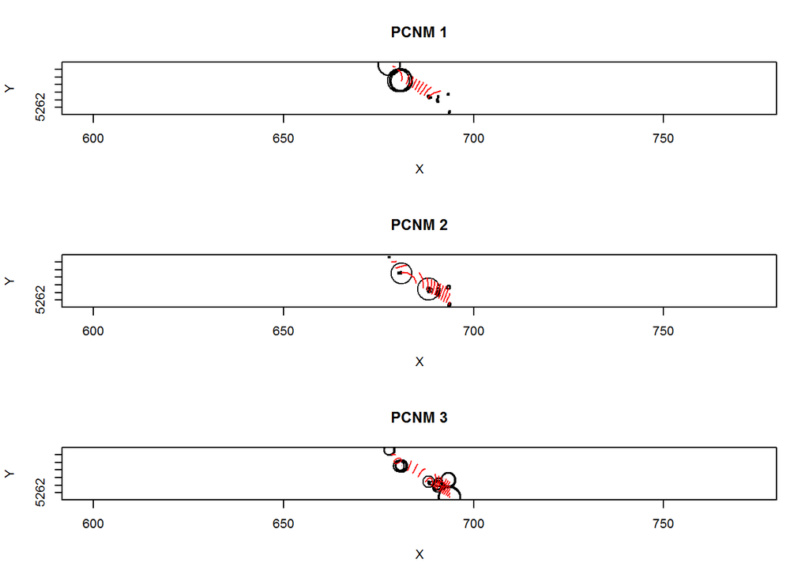

```
##
## Family: gaussian
## Link function: identity
##
## Formula:
## y ~ s(x1, x2, k = 10, bs = "tp", fx = FALSE)
##
## Estimated degrees of freedom:
## 6.13  total = 7.13
##
## REML score: -30.22396
```

```r
ordisurf(pearxy, scores(pcnm1, choi=3), bubble = 4, main = "PCNM 3")
```

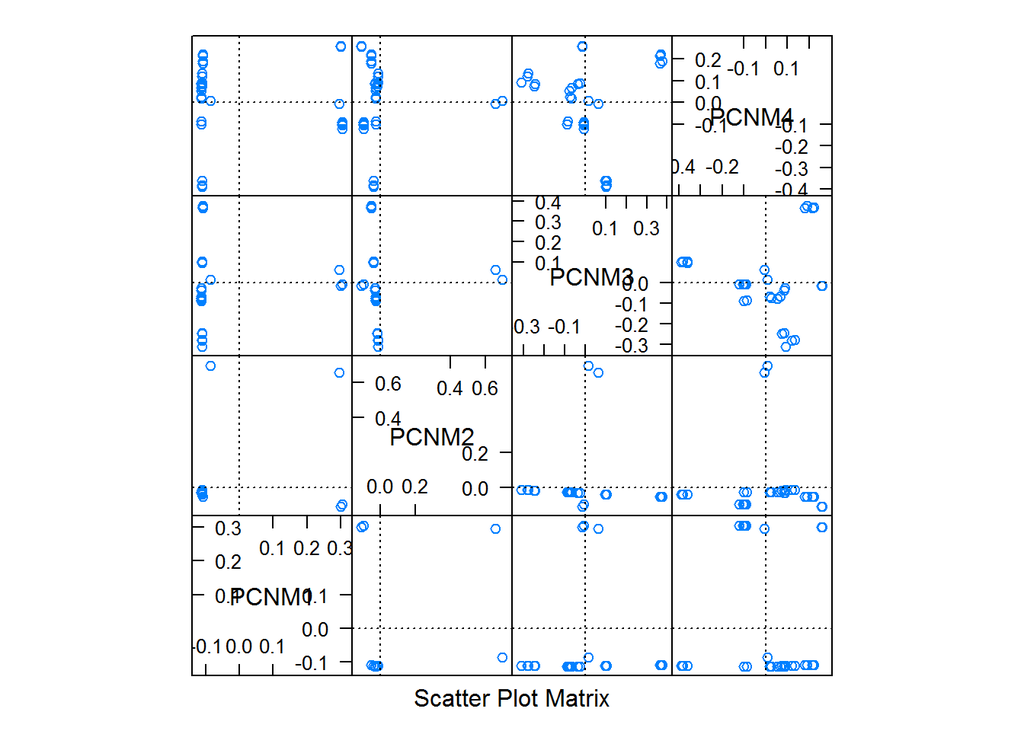

```r
par(op)
## Plot first PCNMs against each other
ordisplom(pcnm1, choices=1:4)
```

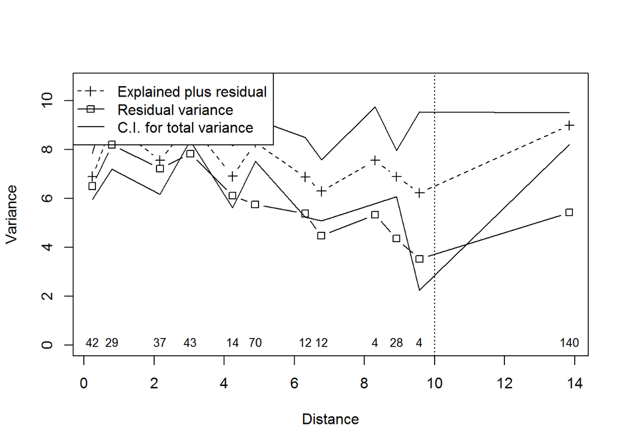

```r
## Weighted PCNM for CCA
rs <- rowSums(BacTab)/sum(BacTab)
pcnmw <- pcnm(dist(pearxy), w = rs)
ord <- cca(BacTab ~ scores(pcnmw))
## Multiscale ordination: residual variance should have no distance
## trend
par(mfrow=c(1,1))
msoplot(mso(ord, pearxy))
```

Fungal community beta diversity

```r
library(vegan)
pcnm1 <- pcnm(dist(pearxy))
op <- par(mfrow=c(3,1))
## Map of PCNMs in the sample plot
ordisurf(pearxy, scores(pcnm1, choi=1), bubble = 4, main = "PCNM 1")
```

```
##
## Family: gaussian
## Link function: identity
##
## Formula:
## y ~ s(x1, x2, k = 10, bs = "tp", fx = FALSE)
##
## Estimated degrees of freedom:
## 8.72  total = 9.72
##
## REML score: -94.04637
```